# IPL_2020

We have the IPL data from 2008-2019 with two datasets one providing the information about each of the delivery in each match over all the seasons called deliveries dataset and the other dataset provides information about each match called the matches dataset. First of all we will analyze the data extracting all the insights from both the datasets and then predict the upcoming IPL season.

ANALYZING IPL - (2008-2019)

Importing the libraries

```python
import numpy as np
import pandas as pd
import matplotlib.pyplot as plt
import seaborn as sns
```

Importing the two datasets - deliveries and matches

```python
from google.colab import drive
drive.mount('/content/drive')

deliveries = pd.read_csv('/content/drive/My Drive/dataset deliveries.csv')
matches = pd.read_csv('/content/drive/My Drive/dataset matches.csv')
```

[output not shown]

Now, looking at the dimensions of both the datasets.

```python
deliveries.shape
```

```
(179078, 21)
```

There are 179078 rows and 21 columns in the deliveries dataset.

```python
matches.shape
```

```
(756, 18)
```

There are 756 rows and 18 columns in the matches dataset.

Now, we will look at the columns of both the datasets.

```python
deliveries.columns
```

```
Index(['match_id', 'inning', 'batting_team', 'bowling_team', 'over', 'ball',
       'batsman', 'non_striker', 'bowler', 'is_super_over', 'wide_runs',
       'bye_runs', 'legbye_runs', 'noball_runs', 'penalty_runs',
       'batsman_runs', 'extra_runs', 'total_runs', 'player_dismissed',
       'dismissal_kind', 'fielder'],
      dtype='object')
```

```python
matches.columns
```

```
Index(['id', 'season', 'city', 'date', 'team1', 'team2', 'toss_winner',
       'toss_decision', 'result', 'dl_applied', 'winner', 'win_by_runs',
       'win_by_wickets', 'player_of_match', 'venue', 'umpire1', 'umpire2',
       'umpire3'],
      dtype='object')
```

Looking at 5 rows of both the datasets.

```python
deliveries.head(5)
```

|  | match_id | inning | batting_team | bowling_team | over | ball | batsman | non_striker | bowler | is_super_over | wide_runs | bye_runs | legbye_runs | noball_runs | penalty_runs | batsman_runs | extra_runs | total_runs | player_dismissed | dismissal_kind | fielder |
| --- | --- | --- | --- | --- | --- | --- | --- | --- | --- | --- | --- | --- | --- | --- | --- | --- | --- | --- | --- | --- | --- |
| 0 | 1 | 1 | Sunrisers Hyderabad | Royal Challengers Bangalore | 1 | 1 | DA Warner | S Dhawan | TS Mills | 0 | 0 | 0 | 0 | 0 | 0 | 0 | 0 | 0 | NaN | NaN | NaN |
| 1 | 1 | 1 | Sunrisers Hyderabad | Royal Challengers Bangalore | 1 | 2 | DA Warner | S Dhawan | TS Mills | 0 | 0 | 0 | 0 | 0 | 0 | 0 | 0 | 0 | NaN | NaN | NaN |
| 2 | 1 | 1 | Sunrisers Hyderabad | Royal Challengers Bangalore | 1 | 3 | DA Warner | S Dhawan | TS Mills | 0 | 0 | 0 | 0 | 0 | 0 | 4 | 0 | 4 | NaN | NaN | NaN |
| 3 | 1 | 1 | Sunrisers Hyderabad | Royal Challengers Bangalore | 1 | 4 | DA Warner | S Dhawan | TS Mills | 0 | 0 | 0 | 0 | 0 | 0 | 0 | 0 | 0 | NaN | NaN | NaN |
| 4 | 1 | 1 | Sunrisers Hyderabad | Royal Challengers Bangalore | 1 | 5 | DA Warner | S Dhawan | TS Mills | 0 | 2 | 0 | 0 | 0 | 0 | 0 | 2 | 2 | NaN | NaN | NaN |

```python
matches.head(5)
```

|  | id | season | city | date | team1 | team2 | toss_winner | toss_decision | result | dl_applied | winner | win_by_runs | win_by_wickets | player_of_match | venue | umpire1 | umpire2 | umpire3 |
| --- | --- | --- | --- | --- | --- | --- | --- | --- | --- | --- | --- | --- | --- | --- | --- | --- | --- | --- |
| 0 | 1 | 2017 | Hyderabad | 2017-04-05 | Sunrisers Hyderabad | Royal Challengers Bangalore | Royal Challengers Bangalore | field | normal | 0 | Sunrisers Hyderabad | 35 | 0 | Yuvraj Singh | Rajiv Gandhi International Stadium, Uppal | AY Dandekar | NJ Llong | NaN |
| 1 | 2 | 2017 | Pune | 2017-04-06 | Mumbai Indians | Rising Pune Supergiant | Rising Pune Supergiant | field | normal | 0 | Rising Pune Supergiant | 0 | 7 | SPD Smith | Maharashtra Cricket Association Stadium | A Nand Kishore | S Ravi | NaN |
| 2 | 3 | 2017 | Rajkot | 2017-04-07 | Gujarat Lions | Kolkata Knight Riders | Kolkata Knight Riders | field | normal | 0 | Kolkata Knight Riders | 0 | 10 | CA Lynn | Saurashtra Cricket Association Stadium | Nitin Menon | CK Nandan | NaN |
| 3 | 4 | 2017 | Indore | 2017-04-08 | Rising Pune Supergiant | Kings XI Punjab | Kings XI Punjab | field | normal | 0 | Kings XI Punjab | 0 | 6 | GJ Maxwell | Holkar Cricket Stadium | AK Chaudhary | C Shamshuddin | NaN |
| 4 | 5 | 2017 | Bangalore | 2017-04-08 | Royal Challengers Bangalore | Delhi Daredevils | Royal Challengers Bangalore | bat | normal | 0 | Royal Challengers Bangalore | 15 | 0 | KM Jadhav | M Chinnaswamy Stadium | NaN | NaN | NaN |

Looking at the information that the datasets provide us about the datatype of columns and number of null and non-null values.

```python
deliveries.info()
```

```
<class 'pandas.core.frame.DataFrame'>
RangeIndex: 179078 entries, 0 to 179077
Data columns (total 21 columns):
 #   Column            Non-Null Count   Dtype
---  ------            --------------   -----
 0   match_id          179078 non-null  int64
 1   inning            179078 non-null  int64
 2   batting_team      179078 non-null  object
 3   bowling_team      179078 non-null  object
 4   over              179078 non-null  int64
 5   ball              179078 non-null  int64
 6   batsman           179078 non-null  object
 7   non_striker       179078 non-null  object
 8   bowler            179078 non-null  object
 9   is_super_over     179078 non-null  int64
 10  wide_runs         179078 non-null  int64
 11  bye_runs          179078 non-null  int64
 12  legbye_runs       179078 non-null  int64
 13  noball_runs       179078 non-null  int64
 14  penalty_runs      179078 non-null  int64
 15  batsman_runs      179078 non-null  int64
 16  extra_runs        179078 non-null  int64
 17  total_runs        179078 non-null  int64
 18  player_dismissed  8834 non-null    object
 19  dismissal_kind    8834 non-null    object
 20  fielder           6448 non-null    object
dtypes: int64(13), object(8)
memory usage: 28.7+ MB
```

We notice that in the deliveries data all the columns contain non-null values except player_dismissed, dismissal_kind and the fielder present. Since, these 3 columns hold not much importance, we neither remove nor add some values.

```python
matches.info()
```

```
<class 'pandas.core.frame.DataFrame'>
RangeIndex: 756 entries, 0 to 755
Data columns (total 18 columns):
 #   Column           Non-Null Count  Dtype
---  ------           --------------  -----
 0   id               756 non-null    int64
 1   season           756 non-null    int64
 2   city             749 non-null    object
 3   date             756 non-null    object
 4   team1            756 non-null    object
 5   team2            756 non-null    object
 6   toss_winner      756 non-null    object
 7   toss_decision    756 non-null    object
 8   result           756 non-null    object
 9   dl_applied       756 non-null    int64
 10  winner           752 non-null    object
 11  win_by_runs      756 non-null    int64
 12  win_by_wickets   756 non-null    int64
 13  player_of_match  752 non-null    object
 14  venue            756 non-null    object
 15  umpire1          754 non-null    object
 16  umpire2          754 non-null    object
 17  umpire3          119 non-null    object
dtypes: int64(5), object(13)
memory usage: 106.4+ KB
```

Looking at the null values present in these 3 columns.

We notice that in the matches data we have null values in city, winner, player_of_match and the 3 umpires. 3 umpires are not that much important, we leave that as these are.

Looking at the null values in the city column.

```python
matches[pd.isnull(matches["city"])]
```

|  | id | season | city | date | team1 | team2 | toss_winner | toss_decision | result | dl_applied | winner | win_by_runs | win_by_wickets | player_of_match | venue | umpire1 | umpire2 | umpire3 |
| --- | --- | --- | --- | --- | --- | --- | --- | --- | --- | --- | --- | --- | --- | --- | --- | --- | --- | --- |

Filling the null values with the city Kanpur

```python
matches['city'].fillna('Kanpur', inplace = True)
```

Looking at the null values present in the winner column

```python
matches[pd.isnull(matches['winner'])]
```

|  | id | season | city | date | team1 | team2 | toss_winner | toss_decision | result | dl_applied | winner | win_by_runs | win_by_wickets | player_of_match | venue | umpire1 | umpire2 | umpire3 |
| --- | --- | --- | --- | --- | --- | --- | --- | --- | --- | --- | --- | --- | --- | --- | --- | --- | --- | --- |

Setting the null values with Draw in the winner column.

```python
matches['winner'].fillna('Draw', inplace = True)
```

Looking at the null values present in the player of match column

```python
matches[pd.isnull(matches['player_of_match'])]
```

|  | id | season | city | date | team1 | team2 | toss_winner | toss_decision | result | dl_applied | winner | win_by_runs | win_by_wickets | player_of_match | venue | umpire1 | umpire2 | umpire3 |
| --- | --- | --- | --- | --- | --- | --- | --- | --- | --- | --- | --- | --- | --- | --- | --- | --- | --- | --- |

Filling the null values with none

```python
matches['player_of_match'].fillna('none', inplace = True)
```

Now, we noticed that in the matches data, seasons are starting from 2017, so sorting the data according to the seasons.

```python
matches = matches.sort_values("season")
matches
```

|  | id | season | city | date | team1 | team2 | toss_winner | toss_decision | result | dl_applied | winner | win_by_runs | win_by_wickets | player_of_match | venue | umpire1 | umpire2 | umpire3 |
| --- | --- | --- | --- | --- | --- | --- | --- | --- | --- | --- | --- | --- | --- | --- | --- | --- | --- | --- |
| 116 | 117 | 2008 | Mumbai | 2008-06-01 | Chennai Super Kings | Rajasthan Royals | Rajasthan Royals | field | normal | 0 | Rajasthan Royals | 0 | 3 | YK Pathan | Dr DY Patil Sports Academy | BF Bowden | RE Koertzen | NaN |
| 109 | 110 | 2008 | Chennai | 2008-05-24 | Rajasthan Royals | Chennai Super Kings | Rajasthan Royals | bat | normal | 0 | Rajasthan Royals | 10 | 0 | JA Morkel | MA Chidambaram Stadium, Chepauk | DJ Harper | SL Shastri | NaN |
| 108 | 109 | 2008 | Delhi | 2008-05-24 | Mumbai Indians | Delhi Daredevils | Delhi Daredevils | field | normal | 0 | Delhi Daredevils | 0 | 5 | KD Karthik | Feroz Shah Kotla | BF Bowden | K Hariharan | NaN |
| 107 | 108 | 2008 | Chandigarh | 2008-05-23 | Deccan Chargers | Kings XI Punjab | Kings XI Punjab | field | normal | 0 | Kings XI Punjab | 0 | 6 | SE Marsh | Punjab Cricket Association Stadium, Mohali | Asad Rauf | SJ Davis | NaN |
| 106 | 107 | 2008 | Chennai | 2008-05-21 | Royal Challengers Bangalore | Chennai Super Kings | Royal Challengers Bangalore | bat | normal | 0 | Royal Challengers Bangalore | 14 | 0 | A Kumble | MA Chidambaram Stadium, Chepauk | DJ Harper | I Shivram | NaN |
| ... | ... | ... | ... | ... | ... | ... | ... | ... | ... | ... | ... | ... | ... | ... | ... | ... | ... | ... |
| 752 | 11412 | 2019 | Chennai | 07/05/19 | Chennai Super Kings | Mumbai Indians | Chennai Super Kings | bat | normal | 0 | Mumbai Indians | 0 | 6 | AS Yadav | M. A. Chidambaram Stadium | Nigel Llong | Nitin Menon | Ian Gould |
| 753 | 11413 | 2019 | Visakhapatnam | 08/05/19 | Sunrisers Hyderabad | Delhi Capitals | Delhi Capitals | field | normal | 0 | Delhi Capitals | 0 | 2 | RR Pant | ACA-VDCA Stadium | NaN | NaN | NaN |
| 727 | 11323 | 2019 | Mohali | 16/04/19 | Kings XI Punjab | Rajasthan Royals | Rajasthan Royals | field | normal | 0 | Kings XI Punjab | 12 | 0 | R Ashwin | IS Bindra Stadium | Anil Chaudhary | Vineet Kulkarni | S Ravi |
| 726 | 11322 | 2019 | Mumbai | 15/04/19 | Royal Challengers Bangalore | Mumbai Indians | Mumbai Indians | field | normal | 0 | Mumbai Indians | 0 | 5 | SL Malinga | Wankhede Stadium | Marais Erasmus | Nitin Menon | Nanda Kishore |
| 755 | 11415 | 2019 | Hyderabad | 12/05/19 | Mumbai Indians | Chennai Super Kings | Mumbai Indians | bat | normal | 0 | Mumbai Indians | 1 | 0 | JJ Bumrah | Rajiv Gandhi Intl. Cricket Stadium | Nitin Menon | Ian Gould | Nigel Llong |

756 rows × 18 columns

Unique teams across all the seasons

```python
unique_teams = deliveries.drop_duplicates(subset = ["batting_team"])
print(unique_teams["batting_team"])
```

```
0                 Sunrisers Hyderabad
125       Royal Challengers Bangalore
248                    Mumbai Indians
373           Rising Pune Supergiants
495                     Gujarat Lions
617             Kolkata Knight Riders
838                   Kings XI Punjab
1084                 Delhi Daredevils
14087             Chennai Super Kings
14335                Rajasthan Royals
14800                 Deccan Chargers
55936            Kochi Tuskers Kerala
56524                   Pune Warriors
165208                 Delhi Capitals
Name: batting_team, dtype: object
```

```python
deliveries_new = deliveries["batting_team"].replace("Rising Pune Supergiant", "Rising Pune Supergiants", inplace = True)
unique_teams = deliveries.drop_duplicates(subset = ["batting_team"])
print(unique_teams["batting_team"])
```

```
0                 Sunrisers Hyderabad
125       Royal Challengers Bangalore
248                    Mumbai Indians
373           Rising Pune Supergiants
495                     Gujarat Lions
617             Kolkata Knight Riders
838                   Kings XI Punjab
1084                 Delhi Daredevils
14087             Chennai Super Kings
14335                Rajasthan Royals
14800                 Deccan Chargers
55936            Kochi Tuskers Kerala
56524                   Pune Warriors
165208                 Delhi Capitals
Name: batting_team, dtype: object
```

Total 14 unique teams.

Unique batsman across all the seasons

```python
unique_batsman = deliveries.drop_duplicates(subset = ["batsman"])
print(unique_batsman["batsman"])
```

```
0            DA Warner
5             S Dhawan
12        MC Henriques
66        Yuvraj Singh
96            DJ Hooda
              ...
172508        A Turner
173597          H Brar
173740    S Rutherford
173863           P Raj
176371         S Singh
Name: batsman, Length: 516, dtype: object
```

There are total 516 unique batsman across the seasons.

Unique bowlers across all the seasons

```python
unique_bowlers = deliveries.drop_duplicates(subset = ["bowler"])
print(unique_bowlers["bowler"])
```

```
0            TS Mills
7         A Choudhary
20          YS Chahal
26          S Aravind
32          SR Watson
             ...
173644         H Brar
173877          P Raj
174950       O Thomas
175365          A Roy
176035      S Warrier
Name: bowler, Length: 405, dtype: object
```

There are total 405 unique bowlers across the seasons.

Extracting the parameters of the matches dataset.

```python
matches_des = matches.describe()
matches_des.drop(["id", "season"], axis = 1)
```

|  | dl_applied | win_by_runs | win_by_wickets |
| --- | --- | --- | --- |
| count | 756.000000 | 756.000000 | 756.000000 |
| mean | 0.025132 | 13.283069 | 3.350529 |
| std | 0.156630 | 23.471144 | 3.387963 |
| min | 0.000000 | 0.000000 | 0.000000 |
| 25% | 0.000000 | 0.000000 | 0.000000 |
| 50% | 0.000000 | 0.000000 | 4.000000 |
| 75% | 0.000000 | 19.000000 | 6.000000 |
| max | 1.000000 | 146.000000 | 10.000000 |

total runs made by each batsman in each match

```python
batsman_grp = deliveries.groupby(["match_id", "inning", "batting_team", "batsman"])
batsmen = batsman_grp["batsman_runs"].sum().reset_index()
batsmen
```

|  | match_id | inning | batting_team | batsman | batsman_runs |
| --- | --- | --- | --- | --- | --- |
| 0 | 1 | 1 | Sunrisers Hyderabad | BCJ Cutting | 16 |
| 1 | 1 | 1 | Sunrisers Hyderabad | DA Warner | 14 |
| 2 | 1 | 1 | Sunrisers Hyderabad | DJ Hooda | 16 |
| 3 | 1 | 1 | Sunrisers Hyderabad | MC Henriques | 52 |
| 4 | 1 | 1 | Sunrisers Hyderabad | S Dhawan | 40 |
| ... | ... | ... | ... | ... | ... |
| 11330 | 11415 | 2 | Chennai Super Kings | MS Dhoni | 2 |
| 11331 | 11415 | 2 | Chennai Super Kings | RA Jadeja | 9 |
| 11332 | 11415 | 2 | Chennai Super Kings | SK Raina | 9 |
| 11333 | 11415 | 2 | Chennai Super Kings | SN Thakur | 2 |
| 11334 | 11415 | 2 | Chennai Super Kings | SR Watson | 84 |

11335 rows × 5 columns

no. of winnings of each team in each season

```python
matches.groupby( "season")["winner"].value_counts()
```

```
season  winner
2008    Rajasthan Royals               13
        Kings XI Punjab                10
        Chennai Super Kings             9
        Delhi Daredevils                7
        Mumbai Indians                  7
                                       ..
2019    Kolkata Knight Riders           6
        Sunrisers Hyderabad             6
        Rajasthan Royals                5
        Royal Challengers Bangalore     5
        Draw                            1
Name: winner, Length: 103, dtype: int64
```

Total number of winnings of each team in each season.

Batsmen aggregates(Runs, Balls, 4s, 6s, Strike Rate)

```python
batsman_grp = deliveries.groupby(["match_id", "inning", "batting_team", "batsman"])
batsmen = batsman_grp["batsman_runs"].sum().reset_index()

# Ignore the wide balls.
balls_faced = deliveries[deliveries["wide_runs"] == 0]
balls_faced = balls_faced.groupby(["match_id", "inning", "batsman"])["batsman_runs"].count().reset_index()
balls_faced.columns = ["match_id", "inning", "batsman", "balls_faced"]
batsmen = batsmen.merge(balls_faced, left_on=["match_id", "inning", "batsman"],
                        right_on=["match_id", "inning", "batsman"], how="left")

fours = deliveries[ deliveries["batsman_runs"] == 4]
sixes = deliveries[ deliveries["batsman_runs"] == 6]
fours_per_batsman = fours.groupby(["match_id", "inning", "batsman"])["batsman_runs"].count().reset_index()
sixes_per_batsman = sixes.groupby(["match_id", "inning", "batsman"])["batsman_runs"].count().reset_index()

fours_per_batsman.columns = ["match_id", "inning", "batsman", "4s"]
sixes_per_batsman.columns = ["match_id", "inning", "batsman", "6s"]
batsmen = batsmen.merge(fours_per_batsman, left_on=["match_id", "inning", "batsman"],
                        right_on=["match_id", "inning", "batsman"], how="left")
batsmen = batsmen.merge(sixes_per_batsman, left_on=["match_id", "inning", "batsman"],
                        right_on=["match_id", "inning", "batsman"], how="left")
batsmen['SR'] = np.round(batsmen['batsman_runs'] / batsmen['balls_faced'] * 100, 2)
for col in ["batsman_runs", "4s", "6s", "balls_faced", "SR"]:
    batsmen[col] = batsmen[col].fillna(0)

dismissals = deliveries[ pd.notnull(deliveries["player_dismissed"])]
dismissals = dismissals[["match_id", "inning", "player_dismissed", "dismissal_kind", "fielder"]]
dismissals.rename(columns={"player_dismissed": "batsman"}, inplace=True)
batsmen = batsmen.merge(dismissals, left_on=["match_id", "inning", "batsman"],
                        right_on=["match_id", "inning", "batsman"], how="left")
matches = matches.sort_values("season")

batsmen = matches[['id','season']].merge(batsmen, left_on = 'id', right_on = 'match_id', how = 'left').drop('id', axis = 1)
batsmen.head()
```

|  | season | match_id | inning | batting_team | batsman | batsman_runs | balls_faced | 4s | 6s | SR | dismissal_kind | fielder |
| --- | --- | --- | --- | --- | --- | --- | --- | --- | --- | --- | --- | --- |
| 0 | 2008 | 117 | 1 | Chennai Super Kings | CK Kapugedera | 8 | 12.0 | 0.0 | 0.0 | 66.67 | caught | SA Asnodkar |
| 1 | 2008 | 117 | 1 | Chennai Super Kings | JA Morkel | 16 | 13.0 | 0.0 | 2.0 | 123.08 | caught | Kamran Akmal |
| 2 | 2008 | 117 | 1 | Chennai Super Kings | MS Dhoni | 29 | 17.0 | 1.0 | 2.0 | 170.59 | NaN | NaN |
| 3 | 2008 | 117 | 1 | Chennai Super Kings | PA Patel | 38 | 33.0 | 5.0 | 0.0 | 115.15 | caught | Kamran Akmal |
| 4 | 2008 | 117 | 1 | Chennai Super Kings | S Badrinath | 6 | 2.0 | 1.0 | 0.0 | 300.00 | NaN | NaN |

From the table, the information about each batsman i.e. the runs made by them, no. of balls faced, number of 4s, 6s, strike rate, dismissal kind and the fielder associated with his dismissal during each match can be seen.

Bowler aggregates

```python
bowler_grp = deliveries.groupby(["match_id", "inning", "bowling_team", "bowler", "over"])
bowlers = bowler_grp["total_runs", "wide_runs", "bye_runs", "legbye_runs", "noball_runs"].sum().reset_index()

bowlers["runs"] = bowlers["total_runs"] - (bowlers["bye_runs"] + bowlers["legbye_runs"])
bowlers["extras"] = bowlers["wide_runs"] + bowlers["noball_runs"]
del( bowlers["bye_runs"])
del( bowlers["legbye_runs"])
del( bowlers["total_runs"])

dismissal_kinds_for_bowler = ["bowled", "caught", "lbw", "stumped", "caught and bowled", "hit wicket"]
dismissals = deliveries[deliveries["dismissal_kind"].isin(dismissal_kinds_for_bowler)]
dismissals = dismissals.groupby(["match_id", "inning", "bowling_team", "bowler", "over"])["dismissal_kind"].count().reset_index()
dismissals.rename(columns={"dismissal_kind": "wickets"}, inplace=True)

bowlers = bowlers.merge(dismissals, left_on=["match_id", "inning", "bowling_team", "bowler", "over"],
                        right_on=["match_id", "inning", "bowling_team", "bowler", "over"], how="left")
bowlers["wickets"] = bowlers["wickets"].fillna(0)
bowlers_over = bowlers.groupby(['match_id', 'inning', 'bowling_team', 'bowler'])['over'].count().reset_index()
bowlers = bowlers.groupby(['match_id', 'inning', 'bowling_team', 'bowler']).sum().reset_index().drop('over', 1)
bowlers = bowlers_over.merge(bowlers, on=["match_id", "inning", "bowling_team", "bowler"], how = 'left')
bowlers['Econ'] = np.round(bowlers['runs'] / bowlers['over'] , 2)
bowlers = matches[['id','season']].merge(bowlers, left_on = 'id', right_on = 'match_id', how = 'left').drop('id', axis = 1)

bowlers.head()
```

|  | season | match_id | inning | bowling_team | bowler | over | wide_runs | noball_runs | runs | extras | wickets | Econ |
| --- | --- | --- | --- | --- | --- | --- | --- | --- | --- | --- | --- | --- |
| 0 | 2008 | 117 | 1 | Rajasthan Royals | MM Patel | 2 | 0 | 0 | 14 | 0 | 0.0 | 7.00 |
| 1 | 2008 | 117 | 1 | Rajasthan Royals | SK Trivedi | 2 | 0 | 0 | 21 | 0 | 0.0 | 10.50 |
| 2 | 2008 | 117 | 1 | Rajasthan Royals | SK Warne | 4 | 1 | 0 | 34 | 1 | 0.0 | 8.50 |
| 3 | 2008 | 117 | 1 | Rajasthan Royals | SR Watson | 4 | 1 | 1 | 29 | 2 | 1.0 | 7.25 |
| 4 | 2008 | 117 | 1 | Rajasthan Royals | Sohail Tanvir | 4 | 1 | 0 | 40 | 1 | 1.0 | 10.00 |

From the table, bowler aggregates i.e. number of overs he bowled, wide runs, no balls, total runs, extra runs given and the number of wickets taken in each match.

Extra runs given by the top 5 bowlers in each season

```python
bowlers_extras = bowlers.groupby(['season', 'bowler'])['extras'].sum().unstack().T
bowlers_extras['Total'] = bowlers_extras.sum(axis=1)
bowlers_extras.sort_values('Total', ascending = False, inplace = True)
bowlers_extras.head(5)
```

| season bowler | 2008 | 2009 | 2010 | 2011 | 2012 | 2013 | 2014 | 2015 | 2016 | 2017 | 2018 | 2019 | Total |
| --- | --- | --- | --- | --- | --- | --- | --- | --- | --- | --- | --- | --- | --- |
| SL Malinga | NaN | 31.0 | 24.0 | 22.0 | 19.0 | 15.0 | 9.0 | 19.0 | NaN | 22.0 | NaN | 11.0 | 172.0 |
| P Kumar | 14.0 | 14.0 | 22.0 | 11.0 | 22.0 | 18.0 | 1.0 | 14.0 | 18.0 | 11.0 | NaN | NaN | 145.0 |
| DJ Bravo | 10.0 | 13.0 | 5.0 | 9.0 | 20.0 | 17.0 | NaN | 10.0 | 13.0 | NaN | 17.0 | 16.0 | 130.0 |
| UT Yadav | NaN | NaN | 10.0 | 5.0 | 18.0 | 20.0 | 15.0 | 15.0 | 7.0 | 16.0 | 12.0 | 11.0 | 129.0 |
| B Kumar | NaN | NaN | NaN | 1.0 | 10.0 | 27.0 | 8.0 | 14.0 | 24.0 | 11.0 | 9.0 | 14.0 | 118.0 |

Top 5 bowlers who gave the maximum number of extra runs in each season. Here, we notice that SL Malinga gave maximum number of extra runs to the batsmen over all the seasons.

Team extra columns for each match, each inning

```python
team_score = deliveries.groupby(['match_id', 'inning'])['total_runs'].sum().unstack().reset_index()
team_score.columns = ['match_id', 'inning', 'Team1_score', 'Team2_score', 'Team1_superover_score', 'Team2_superover_score']
matches_agg = pd.merge(matches, team_score, left_on = 'id', right_on = 'match_id', how = 'outer')

team_extras = deliveries.groupby(['match_id', 'inning'])['extra_runs'].sum().unstack().reset_index()
team_extras.columns = ['match_id', 'inning', 'Team1_extras', 'Team2_extras', 'Team1_superover_extras', 'Team2_superover_extras']
matches_agg = pd.merge(matches_agg, team_extras, on = 'match_id', how = 'outer')
matches_agg.head()
```

|  | id | season | city | date | team1 | team2 | toss_winner | toss_decision | result | dl_applied | winner | win_by_runs | win_by_wickets | player_of_match | venue | umpire1 | umpire2 | umpire3 | match_id | inning_x | Team1_score | Team2_score | Team1_superover_score | Team2_superover_score | inning_y | Team1_extras | Team2_extras | Team1_superover_extras | Team2_superover_extras |
| --- | --- | --- | --- | --- | --- | --- | --- | --- | --- | --- | --- | --- | --- | --- | --- | --- | --- | --- | --- | --- | --- | --- | --- | --- | --- | --- | --- | --- | --- |
| 0 | 117 | 2008 | Mumbai | 2008-06-01 | Chennai Super Kings | Rajasthan Royals | Rajasthan Royals | field | normal | 0 | Rajasthan Royals | 0 | 3 | YK Pathan | Dr DY Patil Sports Academy | BF Bowden | RE Koertzen | NaN | 117 | 163.0 | 164.0 | NaN | NaN | NaN | 7.0 | 14.0 | NaN | NaN | NaN |
| 1 | 110 | 2008 | Chennai | 2008-05-24 | Rajasthan Royals | Chennai Super Kings | Rajasthan Royals | bat | normal | 0 | Rajasthan Royals | 10 | 0 | JA Morkel | MA Chidambaram Stadium, Chepauk | DJ Harper | SL Shastri | NaN | 110 | 211.0 | 201.0 | NaN | NaN | NaN | 7.0 | 9.0 | NaN | NaN | NaN |
| 2 | 109 | 2008 | Delhi | 2008-05-24 | Mumbai Indians | Delhi Daredevils | Delhi Daredevils | field | normal | 0 | Delhi Daredevils | 0 | 5 | KD Karthik | Feroz Shah Kotla | BF Bowden | K Hariharan | NaN | 109 | 176.0 | 179.0 | NaN | NaN | NaN | 9.0 | 3.0 | NaN | NaN | NaN |
| 3 | 108 | 2008 | Chandigarh | 2008-05-23 | Deccan Chargers | Kings XI Punjab | Kings XI Punjab | field | normal | 0 | Kings XI Punjab | 0 | 6 | SE Marsh | Punjab Cricket Association Stadium, Mohali | Asad Rauf | SJ Davis | NaN | 108 | 175.0 | 178.0 | NaN | NaN | NaN | 5.0 | 8.0 | NaN | NaN | NaN |
| 4 | 107 | 2008 | Chennai | 2008-05-21 | Royal Challengers Bangalore | Chennai Super Kings | Royal Challengers Bangalore | bat | normal | 0 | Royal Challengers Bangalore | 14 | 0 | A Kumble | MA Chidambaram Stadium, Chepauk | DJ Harper | I Shivram | NaN | 107 | 126.0 | 112.0 | NaN | NaN | NaN | 4.0 | 12.0 | NaN | NaN | NaN |

No. of runs scored by each team and extra runs it got for each match and each inning.

Top 10 players who got the maximum "Player of Match" title across all the seasons

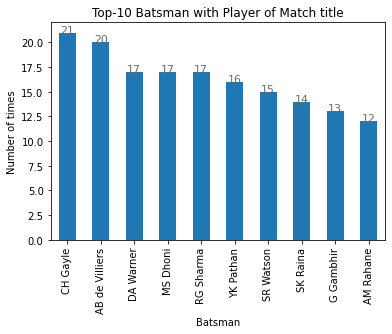

```python
s = matches["player_of_match"].value_counts()[:10].plot(kind = "bar")
for i in s.patches:
    # get_x pulls left or right; get_height pushes up or down
    s.text(i.get_x()+.04, i.get_height(), \
            str(round((i.get_height()), 2)), fontsize=11, color='dimgrey')
s.set_xlabel("Batsman")
s.set_ylabel("Number of times")
s.set_title("Top-10 Batsman with Player of Match title")
```

From the graph we can easily see that CH Gayle won the maximum number of 'Player of Match' title i.e. 21 times.

Top 10 teams with maximum number of winnings across the seasons

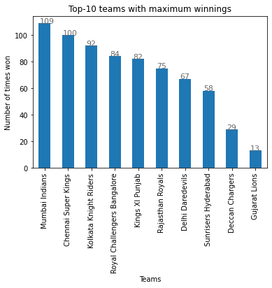

```python
t = matches["winner"].value_counts()[:10].plot(kind = "bar")
for i in t.patches:
    # get_x pulls left or right; get_height pushes up or down
    t.text(i.get_x()+.04, i.get_height(), \
            str(round((i.get_height()), 2)), fontsize=11, color='dimgrey')
t.set_xlabel("Teams")
t.set_ylabel("Number of times won")
t.set_title("Top-10 teams with maximum winnings")
```

From the graph, we can see that Mumbai Indians won maximum no. of matches across all the seasons i.e. 109 times.

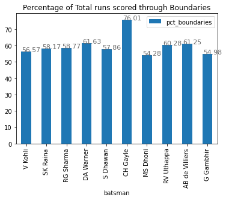

```python
batsman_runs = batsmen.groupby(['batsman'])['batsman_runs', '4s', '6s'].sum().reset_index()
batsman_runs['4s_6s'] = batsman_runs['4s'] * 4 + batsman_runs['6s'] * 6
batsman_runs['pct_boundaries'] = np.round(batsman_runs['4s_6s'] / batsman_runs['batsman_runs'] * 100, 2)
batsman_runs = batsman_runs.sort_values(by = 'batsman_runs', ascending = False)
b = batsman_runs[:10].plot(x= 'batsman', y = 'pct_boundaries', title = 'Percentage of Total runs scored through Boundaries', kind = 'bar')
for i in b.patches:
    # get_x pulls left or right; get_height pushes up or down
    b.text(i.get_x()+.04, i.get_height(), \
            str(round((i.get_height()), 2)), fontsize=11, color='dimgrey')
```

From the graph, we can easily see that CH Gayle scored the maximum percentage of runs i.e. 76.01% through boundaries.

Total no. of winnings by each team in each season

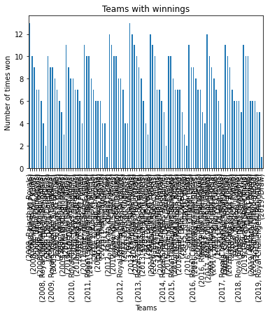

```python
win_sea = matches.groupby("season")
d = win_sea["winner"].value_counts().plot(kind = "bar")
d.set_xlabel("Teams")
d.set_ylabel("Number of times won")
d.set_title("Teams with winnings")
```

Number of times each team won the matches in each season.

Performance of top batsmen over the seasons

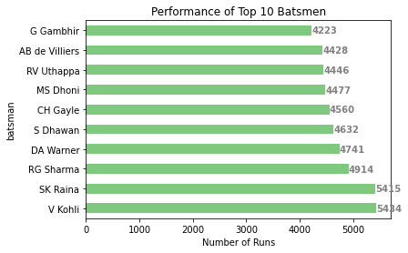

```python
batsmen_runs = batsmen.groupby(['batsman'])['batsman_runs'].sum()
batsmen_runs.sort_values(ascending = False, inplace = True)
k = batsmen_runs[:10].plot(x= 'batsman', y = 'runs', kind = 'barh', colormap = 'Accent')
for i in k.patches:
    plt.text(i.get_width()+0.2, i.get_y()+0.1,
             str(round((i.get_width()), 2)),
             fontsize = 10, fontweight ='bold',
             color ='grey')
k.set_xlabel("Number of Runs")
k.set_title("Performance of Top 10 Batsmen")
```

Performance of top 10 batsmen with Virat Kohli scored the maximum number of runs over all the seasons.

Plotting the performance of top 5 Batsmen over seasons

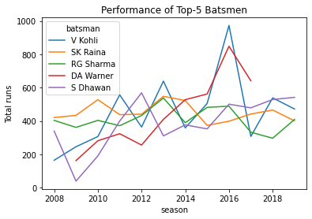

```python
batsman_runsperseason = batsmen.groupby(['season', 'batting_team', 'batsman'])['batsman_runs'].sum().reset_index()
batsman_runsperseason = batsman_runsperseason.groupby(['season', 'batsman'])['batsman_runs'].sum().unstack().T
batsman_runsperseason['Total'] = batsman_runsperseason.sum(axis=1)
batsman_runsperseason = batsman_runsperseason.sort_values(by = 'Total', ascending = False).drop('Total', 1)
ax = batsman_runsperseason[:5].T.plot()
ax.set_ylabel("Total runs")
ax.set_title("Performance of Top-5 Batsmen")
```

Performance of top bowlers over seasons

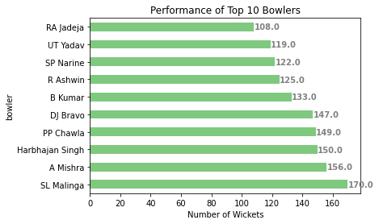

```python
bowlers_wickets = bowlers.groupby(['bowler'])['wickets'].sum()
bowlers_wickets.sort_values(ascending = False, inplace = True)
k = bowlers_wickets[:10].plot(x= 'bowler', y = 'runs', kind = 'barh', colormap = 'Accent')
for i in k.patches:
    plt.text(i.get_width()+0.2, i.get_y()+0.1,
             str(round((i.get_width()), 2)),
             fontsize = 10, fontweight ='bold',
             color ='grey')
k.set_xlabel("Number of Wickets")
k.set_title("Performance of Top 10 Bowlers")
```

From the graph, we see that SL Malinga took the maximum number of wickets i.e. 170 wickets.

Performance of top five bowlers over the seaons

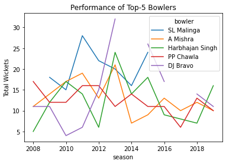

```python
bowlers_wicketsperseason = bowlers.groupby(['season', 'bowling_team', 'bowler'])['wickets'].sum().reset_index()
bowlers_wicketsperseason = bowlers_wicketsperseason.groupby(['season', 'bowler'])['wickets'].sum().unstack().T
bowlers_wicketsperseason['Total'] = bowlers_wicketsperseason.sum(axis=1)
bowlers_wicketsperseason = bowlers_wicketsperseason.sort_values(by = 'Total', ascending = False).drop('Total', 1)
ax = bowlers_wicketsperseason[:5].T.plot()
ax.set_ylabel("Total Wickets")
ax.set_title("Performance of Top-5 Bowlers")
```

Team wins in home city vs other cities

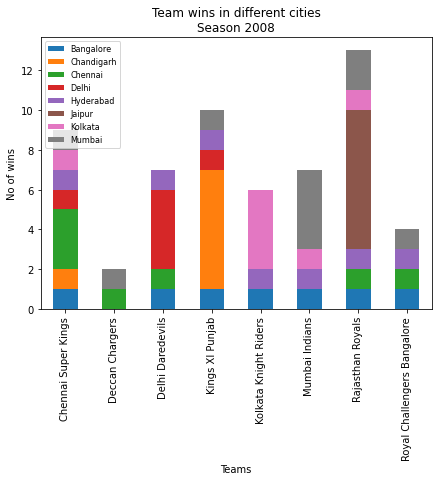

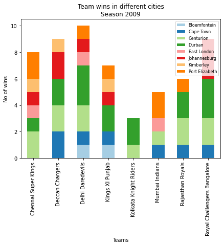

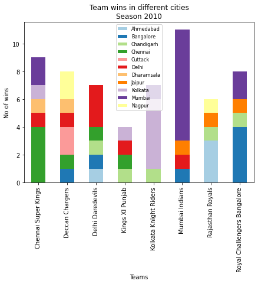

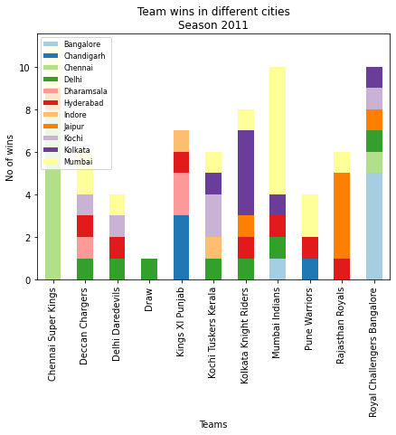

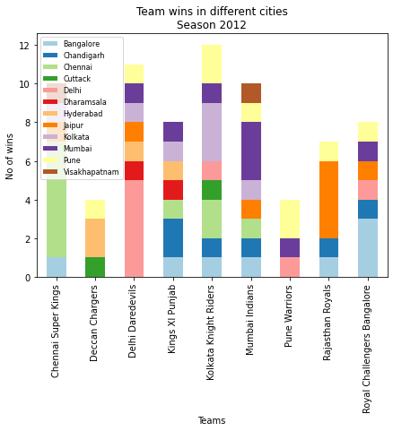

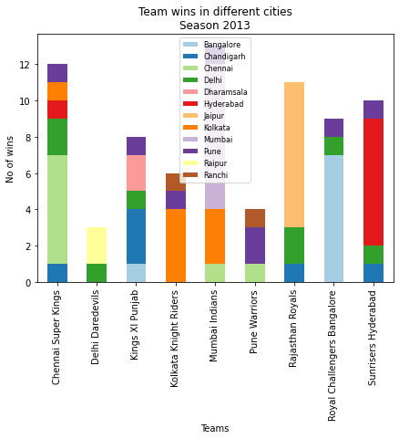

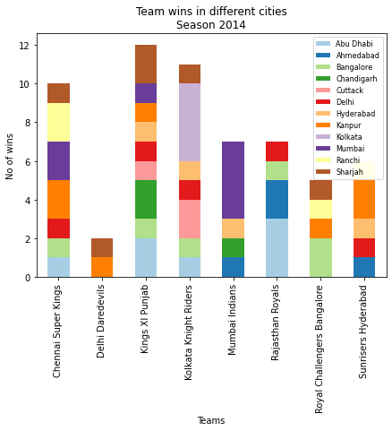

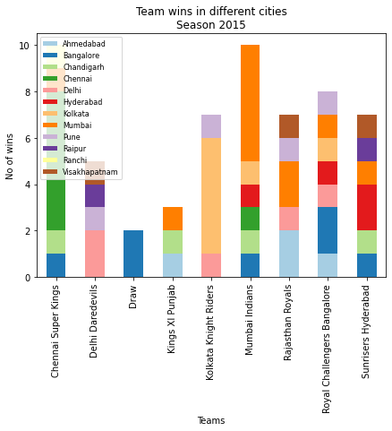

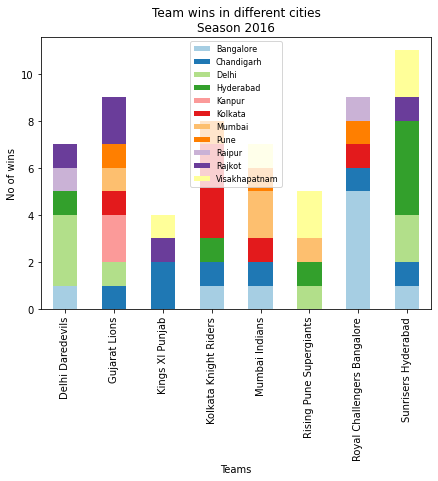

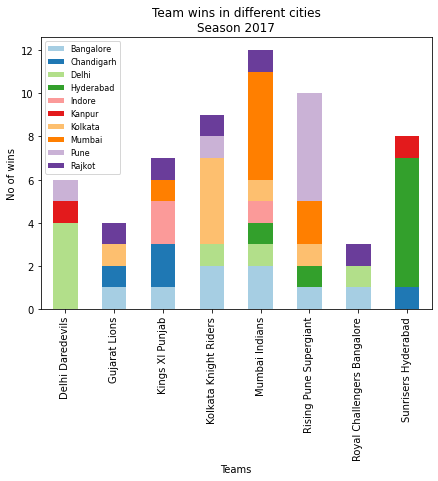

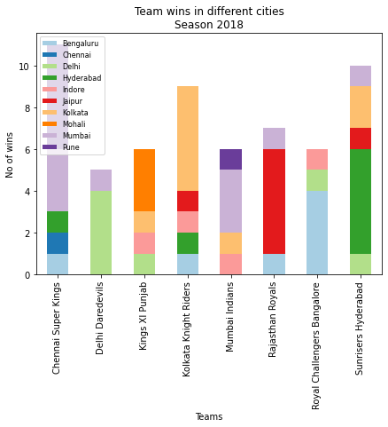

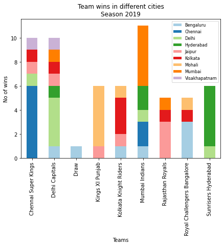

```python
x, y = 2008, 2020
while x < y:
    wins_percity = matches_agg[matches_agg['season'] == x].groupby(['winner', 'city'])['match_id'].count().unstack()
    plot = wins_percity.plot(kind='bar', stacked=True, title="Team wins in different cities\nSeason "+str(x), figsize=(7, 5))
    sns.set_palette("Paired", len(matches_agg['city'].unique()))
    plot.set_xlabel("Teams")
    plot.set_ylabel("No of wins")
    plot.legend(loc='best', prop={'size':8})
    x+=1
```

Making the Predictions

For the columns to be able to assist the model in the prediction, the values should make some sense to the computers. Since they (still) don’t have the ability to understand and draw inference from the text, we need to encode the strings to numeric categorical values.

Encoding team_1, team_2, winner and the toss_winner

```python
matches.replace(['Mumbai Indians','Kolkata Knight Riders','Royal Challengers Bangalore','Deccan Chargers','Chennai Super Kings',
                 'Rajasthan Royals','Delhi Daredevils','Gujarat Lions','Kings XI Punjab', 'Delhi Capitals',
                 'Sunrisers Hyderabad','Rising Pune Supergiants','Rising Pune Supergiant','Kochi Tuskers Kerala','Pune Warriors']
                ,['MI','KKR','RCB','DC','CSK','RR','DD','GL','KXIP', 'Dc', 'SRH','RPS','RPS','KTK','PW'],inplace=True)
encode = {'team1': {'MI':1,'KKR':2,'RCB':3,'DC':4,'CSK':5,'RR':6,'DD':7,'GL':8,'KXIP':9, 'Dc':10, 'SRH':11,'RPS':12,'KTK':13,'PW':14},
          'team2': {'MI':1,'KKR':2,'RCB':3,'DC':4,'CSK':5,'RR':6,'DD':7,'GL':8,'KXIP':9,'Dc':10,'SRH':11,'RPS':12,'KTK':13,'PW':14},
          'toss_winner': {'MI':1,'KKR':2,'RCB':3,'DC':4,'CSK':5,'RR':6,'DD':7,'GL':8,'KXIP':9,'Dc':10,'SRH':11,'RPS':12,'KTK':13,'PW':14},
          'winner': {'MI':1,'KKR':2,'RCB':3,'DC':4,'CSK':5,'RR':6,'DD':7,'GL':8,'KXIP':9,'Dc':10,'SRH':11,'RPS':12,'KTK':13,'PW':14,'Draw':15}}
matches.replace(encode, inplace=True)
matches.head(2)
```

|  | id | season | city | date | team1 | team2 | toss_winner | toss_decision | result | dl_applied | winner | win_by_runs | win_by_wickets | player_of_match | venue | umpire1 | umpire2 | umpire3 |
| --- | --- | --- | --- | --- | --- | --- | --- | --- | --- | --- | --- | --- | --- | --- | --- | --- | --- | --- |
| 116 | 117 | 2008 | Mumbai | 2008-06-01 | 5 | 6 | 6 | field | normal | 0 | 6 | 0 | 3 | YK Pathan | Dr DY Patil Sports Academy | BF Bowden | RE Koertzen | NaN |
| 109 | 110 | 2008 | Chennai | 2008-05-24 | 6 | 5 | 6 | bat | normal | 0 | 6 | 10 | 0 | JA Morkel | MA Chidambaram Stadium, Chepauk | DJ Harper | SL Shastri | NaN |

Winner counts of each team.

```python
s = matches['winner'].value_counts(sort=True)
s
```

```
1     109
5     100
2      92
3      84
9      82
6      75
7      67
11     58
4      29
12     15
8      13
14     12
10     10
13      6
15      4
Name: winner, dtype: int64
```

Toss winner counts of each team

```python
t = matches['toss_winner'].value_counts(sort = True)
t
```

```
1     98
2     92
5     89
9     81
3     81
7     80
6     80
11    46
4     43
14    20
8     15
12    13
10    10
13     8
Name: toss_winner, dtype: int64
```

Graphing both

[figure not shown]

```python
fig = plt.figure(figsize = (8,4))
ax1 = fig.add_subplot(121)
ax1.set_xlabel('Team')
ax1.set_ylabel('Count of toss wins')
ax1.set_title('toss winners')
s.plot(kind = 'bar')

ax2 = fig.add_subplot(122)
t.plot(kind = 'bar')
ax2.set_xlabel('Team')
ax2.set_ylabel('count of matches won')
ax2.set_title('Match winners')
```

Selected columns for prediction

```python
matches = matches[['team1', 'team2', 'city', 'toss_decision', 'toss_winner', 'venue', 'winner']]
matches
```

|  | team1 | team2 | city | toss_decision | toss_winner | venue | winner |
| --- | --- | --- | --- | --- | --- | --- | --- |
| 116 | 5 | 6 | Mumbai | field | 6 | Dr DY Patil Sports Academy | 6 |
| 109 | 6 | 5 | Chennai | bat | 6 | MA Chidambaram Stadium, Chepauk | 6 |
| 108 | 1 | 7 | Delhi | field | 7 | Feroz Shah Kotla | 7 |
| 107 | 4 | 9 | Chandigarh | field | 9 | Punjab Cricket Association Stadium, Mohali | 9 |
| 106 | 3 | 5 | Chennai | bat | 3 | MA Chidambaram Stadium, Chepauk | 3 |
| ... | ... | ... | ... | ... | ... | ... | ... |
| 752 | 5 | 1 | Chennai | bat | 5 | M. A. Chidambaram Stadium | 1 |
| 753 | 11 | 10 | Visakhapatnam | field | 10 | ACA-VDCA Stadium | 10 |
| 727 | 9 | 6 | Mohali | field | 6 | IS Bindra Stadium | 9 |
| 726 | 3 | 1 | Mumbai | field | 1 | Wankhede Stadium | 1 |
| 755 | 1 | 5 | Hyderabad | bat | 1 | Rajiv Gandhi Intl. Cricket Stadium | 1 |

756 rows × 7 columns

Converting into a dataframe and extracting some insights

```python
df = pd.DataFrame(matches)
df.describe()
```

|  | team1 | team2 | toss_winner | winner |
| --- | --- | --- | --- | --- |
| count | 756.000000 | 756.000000 | 756.000000 | 756.000000 |
| mean | 5.661376 | 5.674603 | 5.525132 | 5.484127 |
| std | 3.560882 | 3.528118 | 3.464202 | 3.521139 |
| min | 1.000000 | 1.000000 | 1.000000 | 1.000000 |
| 25% | 3.000000 | 3.000000 | 2.000000 | 2.000000 |
| 50% | 5.000000 | 5.000000 | 5.000000 | 5.000000 |
| 75% | 9.000000 | 8.000000 | 8.000000 | 8.000000 |
| max | 14.000000 | 14.000000 | 14.000000 | 15.000000 |

Finding the null values in every column

```python
df.apply(lambda x: sum(x.isnull()), axis = 0)
```

```
team1            0
team2            0
city             0
toss_decision    0
toss_winner      0
venue            0
winner           0
dtype: int64
```

No null values, hence we can now proceed further.

Encoding the the other 3 categorical variables into variables to apply the models

```python
from sklearn.preprocessing import LabelEncoder
var_mod = ['city', 'toss_decision', 'venue']
le = LabelEncoder()
for i in var_mod:
  df[i] = le.fit_transform(df[i])
df.dtypes
```

```
team1            int64
team2            int64
city             int64
toss_decision    int64
toss_winner      int64
venue            int64
winner           int64
dtype: object
```

All the predictor variables and the predicted value are of same data type.

Looking at the dataset now.

```python
df.head(5)
```

|  | team1 | team2 | city | toss_decision | toss_winner | venue | winner |
| --- | --- | --- | --- | --- | --- | --- | --- |
| 116 | 5 | 6 | 23 | 1 | 6 | 5 | 6 |
| 109 | 6 | 5 | 8 | 0 | 6 | 20 | 6 |
| 108 | 1 | 7 | 10 | 1 | 7 | 9 | 7 |
| 107 | 4 | 9 | 7 | 1 | 9 | 27 | 9 |
| 106 | 3 | 5 | 8 | 0 | 3 | 20 | 3 |

Now, our data is ready, we'll now apply the models.

Import models from scikit learn module:

```python
from sklearn.linear_model import LogisticRegression
from sklearn.model_selection import KFold
from sklearn.model_selection import StratifiedKFold
from sklearn.ensemble import RandomForestClassifier
from sklearn.tree import DecisionTreeClassifier, export_graphviz
from sklearn import metrics
```

Defining the function

```python
def classification_model(model, data, predictors, outcome):
  model.fit(data[predictors],data[outcome])
  predictions = model.predict(data[predictors])
  accuracy = metrics.accuracy_score(predictions,data[outcome])
  print('Accuracy : %s' % '{0:.3%}'.format(accuracy))
  kf = KFold(n_splits=7)
  error = []
  for train, test in kf.split(data):
    train_predictors = (data[predictors].iloc[train,:])
    train_target = data[outcome].iloc[train]
    model.fit(train_predictors, train_target)
    error.append(model.score(data[predictors].iloc[test,:], data[outcome].iloc[test]))

    print('Cross-Validation Score : %s' % '{0:.3%}'.format(np.mean(error)))

    model.fit(data[predictors],data[outcome])
```

```python
from sklearn.ensemble import RandomForestRegressor
outcome_var=['winner']
predictor_var = ['team1','team2','toss_winner']
model = LogisticRegression()
classification_model(model, df,predictor_var,outcome_var)
```

```
Accuracy : 24.603%
Cross-Validation Score : 21.296%
```

[output not shown]

```
Cross-Validation Score : 20.833%
```

```
Cross-Validation Score : 22.840%
```

```
Cross-Validation Score : 24.306%
```

```
Cross-Validation Score : 23.704%
```

```
Cross-Validation Score : 23.611%
Cross-Validation Score : 23.942%
```

This model is showing the accuracy of just 24.603% and cross validation score of approx 24% which is very low.

Now, we'll add more predictors in the model and check the accuracy

```python
model = RandomForestClassifier(n_estimators=100)
outcome_var = ['winner']
predictor_var = ['team1', 'team2', 'venue', 'toss_winner','city','toss_decision']
classification_model(model, df,predictor_var,outcome_var)
```

```
Accuracy : 88.095%
```

```
Cross-Validation Score : 47.222%
```

```
Cross-Validation Score : 46.759%
```

```
Cross-Validation Score : 47.531%
```

```
Cross-Validation Score : 46.991%
```

```
Cross-Validation Score : 46.481%
```

```
Cross-Validation Score : 46.605%
```

```
Cross-Validation Score : 46.958%
```

This model is showing the accuracy of 88.095 % and cross validation score of approx 47% which is far better than the previous one.

```python
df.head(5)
```

|  | team1 | team2 | city | toss_decision | toss_winner | venue | winner |
| --- | --- | --- | --- | --- | --- | --- | --- |
| 116 | 5 | 6 | 23 | 1 | 6 | 5 | 6 |
| 109 | 6 | 5 | 8 | 0 | 6 | 20 | 6 |
| 108 | 1 | 7 | 10 | 1 | 7 | 9 | 7 |
| 107 | 4 | 9 | 7 | 1 | 9 | 27 | 9 |
| 106 | 3 | 5 | 8 | 0 | 3 | 20 | 3 |

Extracting the key value pairs of the encoding.

```python
dicVal = encode['winner']
print(dicVal['MI'])
print(list(dicVal.keys())[list(dicVal.values()).index(1)])
```

```
1
MI
```

PREDICTIONS

```python
team1='RCB'
team2='KKR'
toss_winner='RCB'
input=[dicVal[team1],dicVal[team2],'14',dicVal[toss_winner],'2','1']
input = np.array(input).reshape((1, -1))
output = model.predict(input)
print(list(dicVal.keys())[list(dicVal.values()).index(output)])
```

```
KKR
```

By taking the two teams, venue, toss_winner, city and toss decision into account we see that the model predicted KKR to be the winner.

Making another prediction

```python
team1='DC'
team2='DD'
toss_winner='DC'
input=[dicVal[team1],dicVal[team2], '23', dicVal[toss_winner], '14', '1']
input = np.array(input).reshape((1, -1))
output = model.predict(input)
print(list(dicVal.keys())[list(dicVal.values()).index(output)])
```

```
DD
```

Here, model predicted DD to be the winner taking into account the other predictors.

Importance of the predictors in making the predictions

```python
imp_input = pd.Series(model.feature_importances_, index=predictor_var).sort_values(ascending=False)
print(imp_input)
```

```
team2            0.240657
team1            0.223688
toss_winner      0.175095
venue            0.174394
city             0.156105
toss_decision    0.030060
dtype: float64
```

We see that which two teams are playing the match, are the most important factors as the strongest team has more chances to win the match followed by the venue and toss_winner. Setting the two teams aside, we notice that venue and toss_winner are almost equally important in predicting the winner.

Now, analyzing how winning the toss and winning the match are related from the previous data

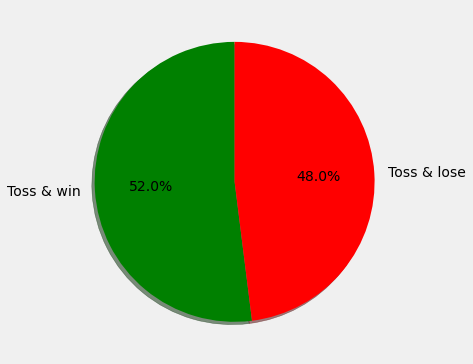

```python
import matplotlib.pyplot as mlt
mlt.style.use('fivethirtyeight')
df_fil=df[df['toss_winner']==df['winner']]
slices=[len(df_fil),(756-len(df_fil))]
mlt.pie(slices,labels=['Toss & win','Toss & lose'],startangle=90,shadow=True,explode=(0,0),autopct='%1.1f%%',colors=['g','r'])
fig = mlt.gcf()
fig.set_size_inches(6,6)
mlt.show()
```

From the graph we notice that in the previous matches 52% of the times the team won after winning the toss and 48% of the times lose. It shows that winning the toss is not that much important from the previous stats.

Now, looking at the other factor i.e. venue Taking the two teams, and the effect on winning the game based on the venue

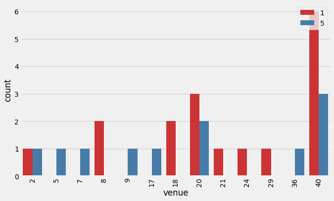

```python
team1=dicVal['MI']
team2=dicVal['CSK']
mtemp=matches[((matches['team1']==team1)|(matches['team2']==team1))&((matches['team1']==team2)|(matches['team2']==team2))]
sns.countplot(x='venue', hue='winner',data=mtemp,palette='Set1')
mlt.xticks(rotation='vertical')
leg = mlt.legend( loc = 'upper right')
fig=mlt.gcf()
fig.set_size_inches(10,6)
mlt.show()
```

We see that team1 i.e. MI won maximum matches at venue 40 against team2 i.e. CSK.

Extracting the venue

```python
le.classes_[40]
```

```
'Wankhede Stadium'
```

Wankhede Stadium is the homeground of MI

Taking another set of teams

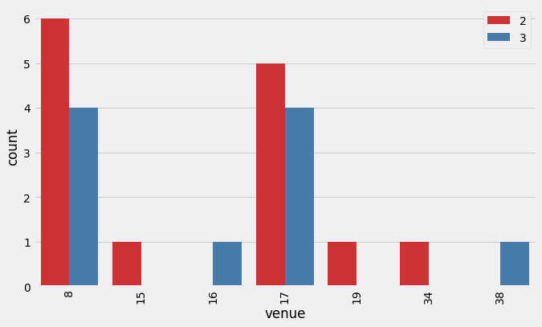

```python
team1=dicVal['RCB']
team2=dicVal['KKR']
mtemp=matches[((matches['team1']==team1)|(matches['team2']==team1))&((matches['team1']==team2)|(matches['team2']==team2))]
sns.countplot(x='venue', hue='winner',data=mtemp,palette='Set1')
mlt.xticks(rotation='vertical')
leg = mlt.legend( loc = 'upper right')
fig=mlt.gcf()
fig.set_size_inches(10,6)
mlt.show()
```

```python
le.classes_[8]
```

```
'Eden Gardens'
```

Eden Gardens is the homeground of KKR and at this venue KKR won maximum number of times against RCB. Hence, we notice that venue holds important factor in predicting the winner amongst the competing teams.